Estadística 1 | 2020

# Guía de Clase del TP5: Inferencia en una muestra

Docentes: Patricia M. Acetta y Agustin Alesso

# Estadística inferencial

Las principales actividades de la Estadística Inferencial son:

1. Utilizar datos muestrales para estimar valores de los parámetros poblacionales, **estimación puntual** y por **intervalos de confianza**.
2. Utilizar datos muestrales para **probar hipótesis** sobre los parámetros poblacionales.

## Parámetros y estimadores

- **Parámetros** son características de la población. Son **fijos y desconocidos**
- **Estimadores** son los estadísticos muestrales (e.g. $\bar{X}$) obtenidos a partir de muestreos aleatorios. Son **variables aleatorias** y tienen una distribución de probabilidades asociada.

| Medida | Parámetro | Estimador |
| --- | --- | --- |
| Media | $\mu$ | $\bar{X}$ |
| Varianza | $\sigma^2$ | $s^2$ |
| Proporción | $\pi$ | $p$ |

# Inferencia en una muestra

En éste TP veremos inferencia en una muestra de los siguientes parámetros poblacionales:

- una media poblacional $\mu$
- una proporción poblacional $\pi$
- una desviación estándar poblacional $\sigma$ o varianza poblacional $\sigma^2$

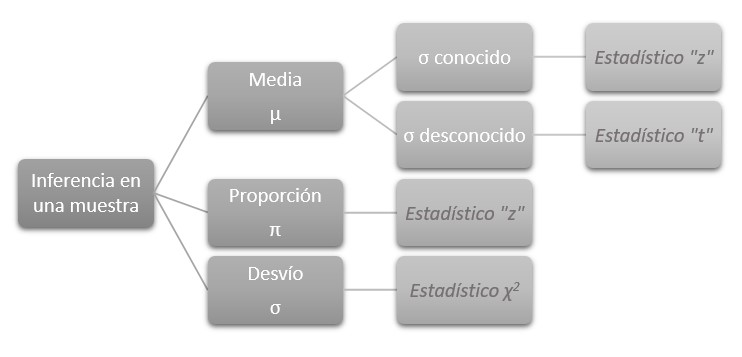

## Intervalos de Confianza

Un intervalo de confianza (o estimación de intervalo) es un rango (o un intervalo) de valores utilizados para estimar el valor real de un parámetro poblacional.

El nivel de confianza es la probabilidad $1-\alpha$ (por ejemplo 0.95, o 95%) de que el intervalo de confianza realmente contenga el parámetro poblacional asumiendo que el proceso de estimación se repite un gran número de veces. El nivel de confianza también se denomina grado de confianza o coeficiente de confianza.

Niveles de confianza más comunes:

| Niveles de confianza | $\alpha$ |
| --- | --- |
| 90% (o 0.90) | 0.10 |
| 95% (o 0.95) | 0.05 |
| 99% (o 0.99) | 0.01 |

Forma general:

$$P(\hat{\theta} - k\sigma_{\hat{\theta}} \leq \theta \leq \hat{\theta} + k\sigma_{\hat{\theta}}) = 1 - \alpha$$

Ésto es:

$$P(EP - ME \leq \theta \leq EP + ME) ) = 1 - \alpha$$
Donde:

- EP: Estimador Puntal
- ME: Margen de Error = Valor Crítico * Error Estándar

## Prueba de Hipótesis

En estadística, una hipótesis es una afirmación o declaración sobre una propiedad de una población.

Una prueba de hipótesis (o prueba de significancia) es un procedimiento para probar una hipótesis sobre una propiedad de una población.

### **Hipótesis**

$H_0$: Hipótesis Nula, es una afirmación de que el valor de un parámetro poblacional (por ejemplo la proporción $\pi$, la media $\mu$ o la desviación estándar $\sigma$) es igual a algún valor declarado.

$H_1$: Hipótesis Alternativa, es una afirmación de que el parámetro tiene un valor que difiere en alguna forma de la hipótesis nula. La forma simbólica de la hipótesis alternativa debe usar uno de los siguientes símbolos: $<$, $>$, $\ne$

Posibles planteos de Hipótesis:

$$H_0: \theta = \theta_0 \quad \text{vs} \quad H_1: \theta \ne \theta_0 \\
H_0: \theta \ge \theta_0 \quad \text{vs} \quad H_1: \theta < \theta_0 \\
H_0: \theta \le \theta_0 \quad \text{vs} \quad H_1: \theta > \theta_0$$

### **Pasos en una Prueba de Hipótesis**

1. $H_0$ y $H_1$: Enunciados de las hipótesis nula y alternativa expresados en forma simbólica
2. Determinar el valor del estadístico de prueba
3. Determinar de la distribución muestral que se utilizará para la prueba de hipótesis
4. Identificación de un valor $p$ y/o el valor crítico (si es una prueba unilateral) o los valores críticos (si es una prueba bilateral.)
5. Conclusión:
   1. ¿Cuál es la decisión? ¿Que sucede con $H_0$?

   | $H_0$ | Conclusión |
   | --- | --- |
   | Se rechaza | Existe evidencia suficiente para rechazar $H_0$, de que… (afirmación original) |
   | No se Rechaza | No existe evidencia suficiente para rechazar $H_0$, de que… (afirmación original) |

   2. ¿Por que se llega a esa decisión? El estadístico con valor p o bien con el valor crítico y nivel de significancia.
   3. Interpretación o consencuencias en el contexto del problema o pregunta de investigacion

*¿Aceptar o no rechazar? Se recomienda la expresión “no se rechaza la hipótesis nula” en lugar de “se acepta la hipótesis nula”. El término “aceptar” es engañoso, ya que implica incorrectamente que la hipótesis nula ha sido probada, y nunca podemos probar una hipótesis nula. La frase “no se rechaza” expresa correctaente que la evidencia disponible no es suficientemente fuerte como para justificar el rechazo de la hipótesis nula.*

### **Errores tipo I y tipo II**

Cuando se prueba una hipótesis nula, llegamos a la conclusión de rechazarla o no rechazarla.

Nuestras conclusiones a veces son correctas y en ocasiones son incorrectas.

- **Error tipo I**: El error de rechazar la hipótesis nula cuando en realidad es verdadera. $\alpha$ (alfa) es la probabilidad de un error tipo I.

  $\alpha$ = $P(\text{error tipo I}) = P(\text{rechazar H0 cuando H0 es verdadera})$
- **Error tipo II**: El error de no rechazar la hipótesis nula cuando en realidad es falsa. $\beta$ es la probabilidad de un error tipo II.

  $\beta$ = $P(\text{error tipo II}) = P(\text{no rechazar H0 cuando H0 es falsa})$

# Inferencia en una media poblacional

Se utiliza una media muestral $\bar X$ con el fin de hacer una **inferencia** sobre el valor de la media poblacional $\mu$.

**Definiciones**:

- **Estimación puntual**: La media muestral x es la mejor estimación puntual (o estimación de valor único) de la media poblacional $\mu$.
- **Intervalo de confianza**: Utilice datos muestrales para construir e interpretar una estimación del intervalo de confianza para el valor real de una media poblacional $\mu$.
- **Prueba de Hipótesis**: Se utiliza una prueba de hipótesis formal para evaluar una afirmación sobre una población con media $\mu$.

## IC de la media ($\mu$) con $\sigma^2$ conocido

Por el Teorema Central de Límite, $\bar{X} \sim N( \mu, \sigma/\sqrt{n})$, estandarizando se obtiene el estadístico $Z$

$$Z = \dfrac{\bar{X} - \mu}{\dfrac{\sigma}{\sqrt{n}}} \sim N (0,1)$$

Por lo tanto el IC de una media poblacional $\mu$ con $\sigma$ conocido, es:

$$IC_{1-\alpha} = \bar{X} \pm Z_{1-\alpha/2} \sigma/\sqrt{n}$$

## Prueba de Hipótesis de ($\mu$) con $\sigma^2$ conocido

**Estadístico de prueba**

$$Z = \dfrac{\bar{X} - \mu_0}{\dfrac{\sigma}{\sqrt{n}}} \sim N(0,1)$$

**Regla decisión**

- Rechazar $H_0$ si $|z| \ge z_{1-\alpha/2}$
- Rechazar $H_0$ si $z \le z_{\alpha}$
- Rechazar $H_0$ si $z \ge z_{1-\alpha}$

**Requisito de normalidad o $n$ > 30**

La prueba t es robusta contra una desviación de la normalidad, lo que significa que la prueba funciona razonablemente bien si la desviación de normalidad no es demasiado extrema.

Si la población original no se distribuye normalmente, usamos la condición $n$ > 30 para justificar el uso de la distribución normal, pero no existe un tamaño de muestra mínimo específico exacto que funcione para todos los casos.Usamos el criterio simplificado de $n$ > 30 como justificación para tratar la distribución de las medias muestrales como una distribución normal, independientemente de qué tanto se desvíe de la normalidad.

## Ejercicio 1

El apio, es una planta muy nutritiva, con propiedades diuréticas y depuradoras de la sangre. Puede alcanzar de 30 a 80cm de altura. El ciclo en verano puede ser de 60-75 días, pero en los meses fríos se puede alargar a 130 días o más para poder completar un apio de buen tamaño.

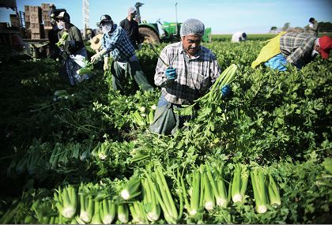

Deben cosecharse con una altura de 75 cm y un desvío de 10 cm, para que la producción mantenga su rentabilidad. Diferecias en ese tamaño, disminuyen la rentabilidad y las características cualitativas del cultivo.

El productor registra las medidas de la última campaña para saber si su producción está dentro de los valores convenientes.

Los datos se encuentran en `apios.xlsx`, donde “Largo”, es la longitud de las plantas de apio expresado en cm.

**Responder:**

1. ¿Cuál es la estimación puntual de la longitud media de los apios?
2. ¿Cuáles son los límites de confianza del 95% de la longitud media de los apios?
3. Pruebe la hipótesis de que el productor está cosechando dentro de los valores rentables. Utilice un nivel de significancia de 0.05.

Importamos los datos:

```r
library(readxl)
apios <- read_xlsx("apios.xlsx")
```

## Item (a).

**¿Cuál es la estimación puntual de la longitud media de los apios?**

El mejor estimador de la media poblacional $\mu$ es la media muestral $\bar X$

```r
xbar <- mean(apios$Largo)
xbar
```

```
[1] 75.88797
```

*Respuesta:* La estimación puntual de la longitud media de los apios es de 75.89 cm.

## Item (b).

Intervalo de Confianza de la media: **¿Cuáles son los límites de confianza del 95% de la longitud media de los apios?**

Queremos obtener: $P(LI \le \mu \le LS)=95\text{%}$, donde LI: límite inferior y LS: límite superior.

En éste ejercicio el desvio poblacional $\sigma$ es Conocido y su valor es: 10 cm, por lo tanto seguiremos el procedimiento de cálculo con el estadístico “z”.

Podemos hacerlo de varias maneras:

Alternativa 1: calculando por separado las partes de un IC

```r
xbar
```

```
[1] 75.88797
```

```r
n <- length(apios$Largo)     # cantidad de observaciones
sigma <- 10                   # desvio poblacional conocido
alfa <- 0.05                 # 1 - 0.95 = 0.05

# valores críticos de la distribución normal: alfa se divide por 2 porque busco los dos extremos de la distribución
zcrit <- qnorm(c(alfa/2, 1-alfa/2))

# error estándar de la media
error <- sigma / sqrt(n)

# Margen de error: valor crítico * error estándar
ME <- zcrit * error

# IC95%  = EP +- ME

IC <- xbar + ME
IC
```

```
[1] 75.38191 76.39403
```

Alternativa 2: utilizando la función `ZTest()` del paquete `DescTools`

```r
library(DescTools)

ZTest<- ZTest(x = apios$Largo,alternative = "two", sd_pop = sigma, conf.level = 0.95)

ZTest
```

```
    One Sample z-test

data:  apios$Largo
z = 293.91, Std. Dev. Population = 10, p-value < 2.2e-16
alternative hypothesis: true mean is not equal to 0
95 percent confidence interval:
 75.38191 76.39403
sample estimates:
mean of x
 75.88797
```

- `x`: son los datos con los cuales haremos inferencia
- `alternative`: para IC siempre es “two”, que significa a ambos lados de la curva
- `sd_pop`: es el desvío que ya conocemos de la población $\sigma$
- `conf.level`: indica el nivel de confianza (NO significancia), por defecto el 0.95 (o 95%)

*Respuesta:* De ambas maneras podemos observar que el Límite Inferior es de 75.3819128 cm y el Límite Superior es de 76.3940339 cm del Intervalo de Confianza del 95% de la longitud media del largo de apio.

$$P(75.3819128 \le \mu \le 76.3940339)=95\text{%}$$

## Item (c).

Prueba de Hipótesis de la media: **Pruebe la hipótesis de que el productor está cosechando dentro de los valores rentables. Utilice un nivel de significancia de 0.05.**

*Seguiremos los pasos de una PH:*

1. Definir las hipótesis

$H_0: \mu = 75$ cm

$H_1: \mu \ne 75$ cm

2. Determinar el valor del estadístico de prueba

El estadístico de prueba es: $Z = \dfrac{\bar{X} - \mu_0}{\dfrac{\sigma}{\sqrt{n}}}$

```r
mu<- 75

z_calc <- (xbar - mu)/(sigma/sqrt(n))
z_calc
```

```
[1] 3.439106
```

3. Determinar de la distribución muestral que se utilizará para la prueba de hipótesis

$$Z \sim N(0,1)$$

4. Identificación de un valor $p$ y/o el(los) valor(es) crítico(s)

En función de la distribución determinada en el paso anterior, buscaremos los valores críticos ya que es una prueba **bilateral** como lo determina la $H_1$ con el símbolo $\ne$.

Alternativa 1: calculando por separado las partes de una PH

Tomando decisión a través de los valores críticos:

```r
alfa <- 0.05
z_crit <- qnorm(p = c(alfa/2, 1- alfa/2))      # alfa se divide por dos porque la prueba es bilateral

z_crit
```

```
[1] -1.959964  1.959964
```

[output not shown]

[output not shown]

[output not shown]

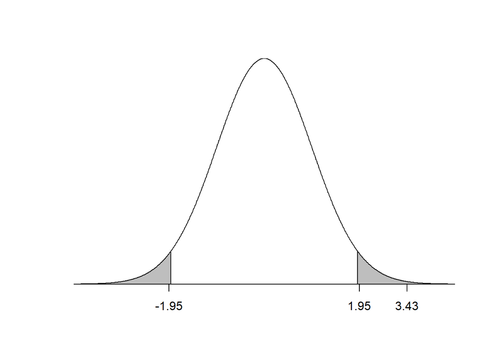

*El área gris corresponde a la región de rechazo, el estadistico de prueba o calculado, 3.4391059, cae en Zona de Rechazo*

Tomando decisión a través del valor $p$:

```r
pvalue <- pnorm(z_calc, lower.tail = z_calc < 0) * 2   # se multipla por 2 porque la prueba es bilateral
pvalue
```

```
[1] 0.0005836388
```

Alternativa 2: utilizando la función `ZTest()` del paquete `DescTools`

```r
library(DescTools)

ZTest<- ZTest(x = apios$Largo, alternative = "two", mu = mu, sd_pop = sigma)

ZTest
```

```
    One Sample z-test

data:  apios$Largo
z = 3.4391, Std. Dev. Population = 10, p-value = 0.0005836
alternative hypothesis: true mean is not equal to 75
95 percent confidence interval:
 75.38191 76.39403
sample estimates:
mean of x
 75.88797
```

- `x`: son los datos con los cuales haremos inferencia
- `alternative`: en PH lo determina el signo de $H_1$
- `mu` es el valor de la media poblacional que estoy contrastando en las hipótesis
- `sd_pop`: es el desvío que ya conocemos de la población $\sigma$
- `conf.level`: indica el nivel de confianza (NO significancia)

**Aclaración**: en ninguna parte de la Alternativa 2, se especifica el $\alpha$ o nivel de significancia, ya que lo que hacemos es tomar el valor $p$ de la salida y lo comparamos con el $\alpha$ que nos indique la consigna

5. Conclusión COMPLETA:
- Si concluyo con los valores críticos:

Existe evidencia suficiente para rechazar la $H_0$, ya que el estadístico de prueba se encuentra en la región de rechazo, por lo tanto no podemos afirmar que la longitud media del largo de los apios sea de 75 cm, no podemos afirmar que el productor éste cosechando en valores rentables.

- Si concluyo con el valor $p$:

Existe evidencia suficiente para rechazar la $H_0$, ya que el valor $p$ (5.836388110^{-4}) es menor al nivel de significancia ($\alpha$), por lo tanto no podemos afirmar que la longitud media del largo de los apios sea de 75 cm, no podemos afirmar que el productor éste cosechando en valores rentables.

## IC de la media ($\mu$) con $\sigma$ desconocido

**Distribución t de Student**

Si una población tiene una distribución normal, entonces la Distribución t de Student:

$$t = \dfrac{\bar{X} - \mu}{\dfrac{s}{\sqrt{n}}} \sim t_{n-1}$$

Por lo tanto el IC de una media poblacional $\mu$ con $\sigma$ desconocido, es:

$$P \left( \bar{X} + t_{\alpha/2, n-1} \dfrac{s}{\sqrt{n}} \leq \mu \leq \bar{X} + t_{1-\alpha/2, n-1} \dfrac{s}{\sqrt{n}} \right) = 1 - \alpha$$

## Prueba de Hipótesis de ($\mu$) con $\sigma^2$ desconocido

**Estadístico de prueba**

$$t = \dfrac{\bar{X} - \mu_0}{\dfrac{s}{\sqrt{n}}} \sim t_{n-1}$$

**Regla decisión**

- Rechazar $H_0$ si $|t| \ge t_{1-\alpha/2, n-1}$
- Rechazar $H_0$ si $t \le t_{\alpha, n-1}$
- Rechazar $H_0$ si $t \ge t_{1-\alpha, n-1}$

## Ejercicio 2

La resistencia mecánica a la penetración (RP) es una propiedad del suelo que influye sobre el desarrollo del sistema radical. Valores superiores a 2 MPa implican limitaciones para el cultivo por lo que se aconseja realizar algun tipo de labranza vertical. Un asesor sospecha que en un lote, producto de la compactación, la RP es superior al umbral crítico (2 MPa). Para corroborar éstos datos se realiza un muestreo con un penetrómetro de campo. Los datos se encuentran en el archivo `penetrometro.xlsx`, donde RP es la resistencia a la penetración explesada en MPa (megapascales).

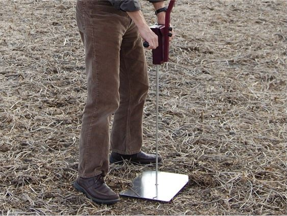

**Responder:**

1. ¿Cuál es la estimación puntual de resistencia a la penetración media?
2. ¿Cuáles son los límites de confianza del 95% de resistencia a la penetración media?
3. ¿Hay evidencias suficientes para decir que el lote tiene problemas de compactación (RP > 2 MPa)? Utilice un nivel de significancia de 0.05.

Importamos los datos:

```r
library(readxl)
resistencia <- read_xlsx("penetrometro.xlsx")
```

## Item (a).

Estimación puntual: **¿Cuál es la estimación puntual de resistencia a la penetración media?**

El mejor estimador de la media poblacional $\mu$ es la media muestral $\bar X$

```r
xbar <- mean(resistencia$RP)
xbar
```

```
[1] 1.99539
```

## Item (b).

Intervalo de Confianza de la media: **¿Cuáles son los límites de confianza del 95% de resistencia a la penetración media?**

Queremos obtener: $P(LI \le \mu \le LS)=95\text{%}$, donde LI: límite inferior y LS: límite superior.

En éste ejercicio el desvio poblacional $\sigma$ es DesConocido, por lo tanto seguiremos el procedimiento de cálculo con el estadístico “t”, utilizando su mejor estimador, el desvío muestral $S$.

Podemos hacerlo de varias maneras:

Alternativa 1: calculando por separado las partes de un IC

```r
xbar
```

```
[1] 1.99539
```

```r
n <- length(resistencia$RP)  # cantidad de observaciones
S <- sd(resistencia$RP)       # desvio muestral
alfa <- 0.05                 # 1 - 0.95 = 0.05

# valores críticos de la distribución normal: alfa se divide por 2 porque busco los dos extremos de la distribución
tcrit <- qt(c(alfa/2, 1-alfa/2), df = n - 1)       #df: grados de libertad

# error estándar de la media
error <- S / sqrt(n)

# Margen de error: valor crítico * error estándar
ME <- tcrit * error

# IC95%  = EP +- ME

IC <- xbar + ME
IC
```

```
[1] 1.990356 2.000424
```

Alternativa 2: utilizando la función `t.test()` del paquete base de R

```r
ttest<- t.test(x = resistencia$RP, alternative = "two")

ttest
```

```
    One Sample t-test

data:  resistencia$RP
t = 777.85, df = 999, p-value < 2.2e-16
alternative hypothesis: true mean is not equal to 0
95 percent confidence interval:
 1.990356 2.000424
sample estimates:
mean of x
  1.99539
```

- `x`: son los datos con los cuales haremos inferencia
- `alternative`: para IC siempre es “two”, que significa a ambos lados de la curva
- `conf.level`: indica el nivel de confianza (NO significancia), por defecto el 0.95 (o 95%)

*Respuesta:* De ambas maneras podemos observar que el Límite Inferior es de 1.9903561 MPa y el Límite Superior es de 2.0004239 MPa del Intervalo de Confianza del 95% de la resistencia a la penetración media de los suelos.

$$P(1.9903561 \le \mu \le 2.0004239)=95\text{%}$$

## Item (c).

Prueba de Hipótesis de la media: **¿Hay evidencias suficientes para decir que el lote tiene problemas de compactación (RP > 2 MPa)? Utilice un nivel de significancia de 0.05.**

*Seguiremos los pasos de una PH:*

1. Definir las hipótesis

$H_0: \mu \le 2$ MPa

$H_1: \mu > 2$ MPa

2. Determinar el valor del estadístico de prueba

El estadístico de prueba es: $t = \dfrac{\bar{X} - \mu}{\dfrac{s}{\sqrt{n}}}$

```r
mu<- 2

t_calc <- (xbar - mu)/(S/sqrt(n))
t_calc
```

```
[1] -1.797079
```

3. Determinar de la distribución muestral que se utilizará para la prueba de hipótesis

Continuaremos con la Distribución “t”, dado que el desvio poblacional $\sigma$ es desconocido, utilizaremos su mejor estimador $S$.

$$t \sim t_{n-1}$$

4. Identificación de un valor $p$ y/o el(los) valor(es) crítico(s)

En función de la distribución determinada en el paso anterior, buscaremos el valor crítico (uno sólo), ya que es una prueba **unilateral** como lo determina la $H_1$ con el símbolo $>$.

Alternativa 1: calculando por separado las partes de una PH

Tomando decisión a través de los valores críticos:

```r
alfa <- 0.05
t_crit <- qt(p = alfa, df = n-1, lower.tail = FALSE)
# lower.tail = FALSE porque H1 tiene simbolo >
# alfa NO se divide por dos porque la prueba es unilateral

t_crit
```

```
[1] 1.64638
```

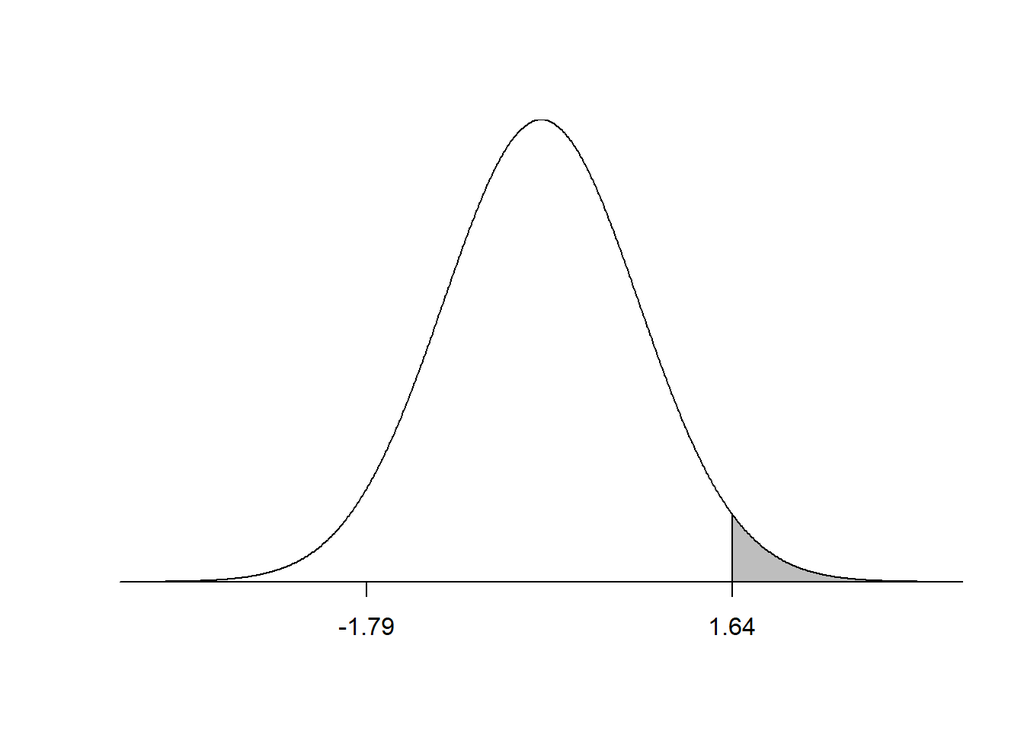

*Región de rechazo: a la derecha de 1.6463803 (a la derecha por el simbolo $>$ en $H_1$), área de color gris. El éstadístico de prueba -1.7970793 cae en Región de No Rechazo*

Tomando decisión a través del valor $p$:

```r
pvalue <- pt(t_calc, df = n-1, lower.tail = F)
# lower.tail = FALSE porque H1 tiene simbolo >

pvalue
```

```
[1] 0.9636875
```

*Ésto significa que el área bajo la curva a la derecha del estadístico de prueba t = -1.7970793 es de 0.9636875*

Alternativa 2: utilizando la función `t.Test()` del paquete base de R

```r
ttest<- t.test(x = resistencia$RP, alternative = "greater", mu = mu)

ttest
```

```
    One Sample t-test

data:  resistencia$RP
t = -1.7971, df = 999, p-value = 0.9637
alternative hypothesis: true mean is greater than 2
95 percent confidence interval:
 1.991167      Inf
sample estimates:
mean of x
  1.99539
```

- `x`: son los datos con los cuales haremos inferencia
- `alternative`: en PH lo determina el signo de $H_1$
- `mu` es el valor de la media poblacional que estoy contrastando en las hipótesis
- `conf.level`: indica el nivel de confianza (NO significancia)

**Aclaración**: en ninguna parte de la Alternativa 2, se especifica el $\alpha$ o nivel de significancia, ya que lo que hacemos es tomar el valor $p$ de la salida y lo comparamos con el $\alpha$ que nos indique la consigna

5. Conclusión COMPLETA:
- Si concluyo con los valores críticos:

No existe evidencia suficiente para rechazar la $H_0$, ya que el estadístico de prueba se encuentra en la región de aceptación, por lo tanto no podemos indicar que el lote tenga valores de RP menores o iguales a 2 MPa, es decir, no podemos indicar que tiene problemas de compactación.

- Si concluyo con el valor $p$:

No existe evidencia suficiente para rechazar la $H_0$, ya que el valor $p$ (0.9636875) es mayor al nivel de significancia ($\alpha=0.05$), por lo tanto no podemos rechazar que el lote tenga valores de RP menores o iguales a 2 MPa, es decir, no podemos indicar que tiene problemas de compactación.

# Inferencia en una proporción poblacional

Se utiliza una proporcón muestral $p$ con el fin de hacer una **inferencia** sobre el valor de la proporción poblacional $\pi$.

**Definiciones**

- **Estimación puntual**: La proporción muestral (expresada por $p$) es la mejor estimación puntual (o estimación de un solo valor) de la proporción poblacional $\pi$.

Si $X \sim \mathrm{Binom}(n, \pi)$, la proporción muestral $p = x/n$ es un estimador insesgado de $\pi$ y su varianza es $\sigma^2_p = \dfrac{pq}{n}$ que puede estimarse con $p$ y $q$

Si $n$ es suficientemente grande $p \sim N \left(\pi, \sqrt{\dfrac{\pi(1-\pi)}{n}} \right)$, y estandarizando: $Z = \dfrac{p - \pi}{\sqrt{\dfrac{pq}{n}}} \sim N(0,1)$

- **Intervalo de confianza**: Utilizamos una proporción muestral $p$ para construir una estimación del intervalo de confianza del verdadero valor de una proporción poblacional $\pi$.

$$P \left( p + Z_{\alpha/2} \sqrt{\dfrac{pq}{n}} \leq \pi \leq p + Z_{1-\alpha/2} \sqrt{\dfrac{pq}{n}} \right) = 1 - \alpha$$

- **Prueba de Hipótesis**: Procedimiento completo para probar una hipótesis hecha sobre una proporción poblacional $\pi$.

Estadístico de prueba

$$Z = \dfrac{p - \pi_0}{\sqrt{\dfrac{\pi_0(1-\pi_0)}{n}}} \sim N(0,1)$$

Regla decisión

- Rechazar $H_0$ si $|Z| \ge Z_{1-\alpha/2}$
- Rechazar $H_0$ si $Z \le Z_{\alpha}$
- Rechazar $H_0$ si $Z \ge Z_{1-\alpha}$

## Ejercicio 3

El proveedor de un insecticida para control de barrenador del brote de soja (*Epinotia aporema*) afirma que su producto tiene una eficacia de mayor al 60%. Para verificar dicha afirmación, se condujo un experimento en donde se seleccionaron 950 plantas con barrenador del brote y se aplico se le aplicó la dosis de producto recomendada. Los datos se encuentran en el archivo `barrenador.xlsx`, donde “Control”, indica si el producto controló o no al barrenador.

[figure not shown]

**Responder:**

1. ¿Cuál es la estimación puntual de la proporción de eficacia del insecticida?
2. ¿Cuáles son los límites de confianza del 99% de la proporción de eficacia del insecticida?
3. ¿Esta evidencia es suiciente para concluir que la afirmación del proveedor es correcta? Utilice un nivel de significancia de 0.05.

Importamos los datos:

```r
library(readxl)
barrenador <- read_xlsx("barrenador.xlsx")
```

## Item (a).

Estimación puntual: **¿Cuál es la estimación puntual de la proporción de eficacia del insecticida?**

El mejor estimador de la proporción poblacional $\pi$ es la media muestral $p$

Primero determinamos cuantas muestras controló y cuantas no:

```r
library(dplyr)

total <- barrenador %>%
  group_by(Control) %>%
  count()
total
```

```
# A tibble: 2 x 2
# Groups:   Control [2]
  Control     n
  <chr>   <int>
1 no        430
2 si        520
```

Nos indica que controló en 520 muestras y No controlo en 430 muestras, de un total de 950 muestras.

Luego calculamos la proporción de plantas controladas por el producto:

```r
p <- 520/950
p
```

```
[1] 0.5473684
```

*Respuesta:* La proporción de plantas controladas por el producto es de 0.5474 o 54.74%.

## Item (b).

Intervalo de Confianza: **¿Cuáles son los límites de confianza del 99% de la proporción de eficacia del insecticida?**

Queremos obtener: $P(LI \le \pi \le LS)=99\text{%}$, donde LI: límite inferior y LS: límite superior.

```r
n <- 950
alfa <- 0.01        #  1 - 0.99 = 0.01

# Valores hipoteticos (poblacionales)
p0 <- 0.60              # lo que afirman que controla el producto
q0 <- 1-p0

# Valores observados
p                     # ya lo calculamos antes
```

```
[1] 0.5473684
```

```r
q <- 1 - p

# valores criticos (a los 2 extremos de la distribución para clacular LI y LS)
z_crit <- qnorm(p = c(alfa/2, 1-alfa/2))
z_crit
```

```
[1] -2.575829  2.575829
```

```r
# error estándar de la media
error <- sqrt(p*q/n)

# Margen de error: valor crítico * error estándar
ME <- z_crit * error

# IC95%  = EP +- ME

IC <- p + ME
IC
```

```
[1] 0.5057709 0.5889660
```

*Respuesta:* Podemos observar que el Límite Inferior es de 0.5057709 cm y el Límite Superior es de 0.588966 cm del Intervalo de Confianza del 99% de la verdadera proporción de plantas controladas por el insecticida.

$$P(0.5057709 \le \pi \le 0.588966)=99\text{%}$$

## Item (c).

Prueba de Hipótesis: **¿Esta evidencia es suiciente para concluir que la afirmación del proveedor es correcta? Utilice un nivel de significancia de 0.05.**

*Seguiremos los pasos de una PH:*

1. Definir las hipótesis

$H_0: \pi \ge 60$ %

$H_1: \pi < 60$ %

2. Determinar el valor del estadístico de prueba

El estadístico de prueba es: $Z = \dfrac{p - \pi_0}{\sqrt{\dfrac{\pi_0(1-\pi_0)}{n}}}$

```r
# Ya cargamos algunos datos en el item anterior:
n
```

```
[1] 950
```

```r
p
```

```
[1] 0.5473684
```

```r
p0
```

```
[1] 0.6
```

```r
# Estadístico de prueba
z_calc <- (p - p0) / sqrt(p0*(1-p0)/n)
z_calc
```

```
[1] -3.311331
```

3. Determinar la distribución muestral que se utilizará para la prueba de hipótesis

$$Z \sim N(0,1)$$

4. Identificación de un valor $p$ y/o el(los) valor(es) crítico(s)

En función de la distribución determinada en el paso anterior, buscaremos el valor crítico (uno sólo), ya que es una prueba **unilateral** como lo determina la $H_1$ con el símbolo $<$.

Alternativa 1: calculando por separado las partes de una PH

Tomando decisión a través de los valores críticos:

```r
# Valor crítico para alfa = 5%
alfa <- 0.05
z_crit <- qnorm(p = alfa)
# lower.tail por defecto es TRUE ya que H1 tiene simbolo <
z_crit
```

```
[1] -1.644854
```

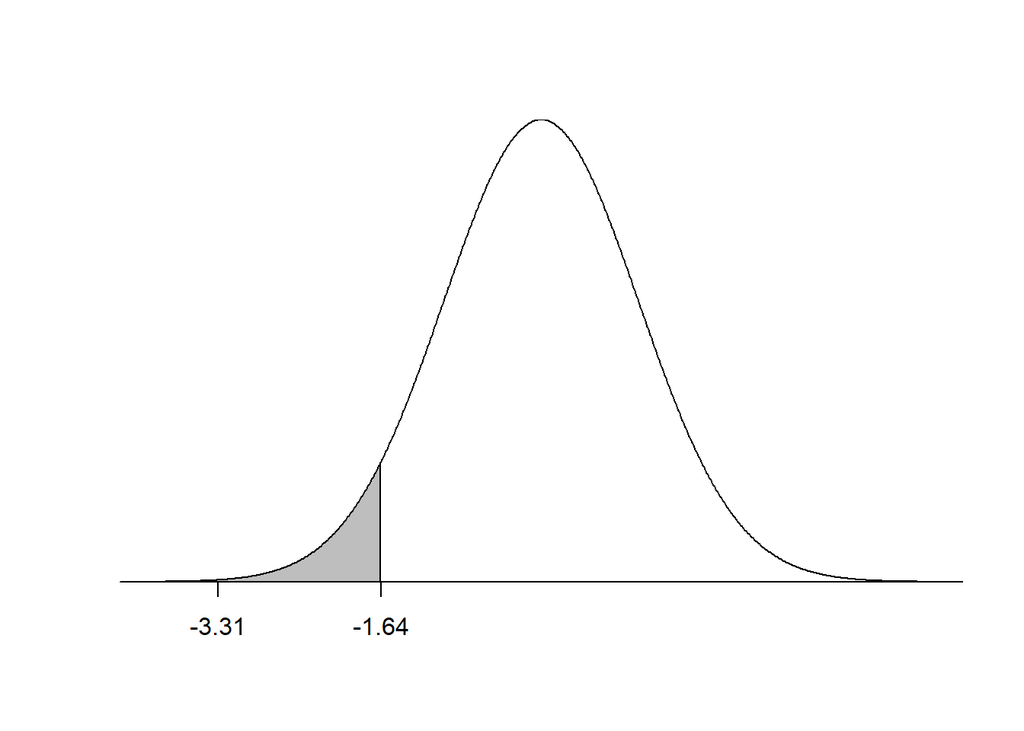

*Región de rechazo: a la izquierda de -1.6448536 (a la izquierda por el simbolo $<$ en $H_1$), área de color gris. El estadístico de prueba, -3.3113309 cae en Región de Rechazo.*

Tomando decisión a través del valor $p$:

```r
pvalue <- pnorm(z_calc, lower.tail = T)
# lower.tail = TRUE porque H1 tiene simbolo <

pvalue
```

```
[1] 0.0004642667
```

*Ésto significa que el área bajo la curva a la izquierda del estadístico de prueba Z = -3.3113309 es de 4.642667110^{-4}*

5. Conclusión COMPLETA:
- Si concluyo con los valores críticos:

Existe evidencia suficiente para rechazar la $H_0$, ya que el estadístico de prueba se encuentra en la región de rechazo, por lo tanto no podemos afirmar que verdadera proporción de plantas controladas por el insecticida sea $\ge 60$%.

# Inferencia de una desviación estándar o varianza poblacionales

Se utiliza una desviación $S$ o varianza $S^2$ muestral con el fin de hacer una **inferencia** sobre el valor de la desviación $\sigma$ o varianza $\sigma^2$ poblacionales, respectivamente.

**Definiciones**

- **Estimación puntual**: La desviación $S$ o varianza $S^2$ muestrales son las mejores estimaciones puntuales (o estimación de un solo valor) de la desviación $S$ o varianza $S^2$ muestrales, respectivamente.

El estimador de $\sigma^2$ es $s^2$ y el estadístico $X^2$ calculado a partir de $s^2$ tiene distribución asimétrica $\chi^2$

$$X^2 = \dfrac{(n-1)s^2}{\sigma^2} \sim \chi^2_{n-1}$$

- **Intervalo de confianza**: Utilizaremos una desviación $S$ o varianza $S^2$ muestrales, para construir una estimación del intervalo de confianza del verdadero valor de una desviación estándar $\sigma$ o una varianza $\sigma^2$ poblacionales.

$$P \left( \dfrac{(n-1)s^2}{\chi^2_{1-\alpha/2, n-1}} \leq \sigma^2 \leq \dfrac{(n-1)s^2}{\chi^2_{\alpha/2, n-1}} \right) = 1 - \alpha$$

- **Prueba de Hipótesis**: Realizaremos una prueba de hipótesis de una afirmación hecha sobre una desviación estándar $\sigma$ o una varianza $\sigma^2$ poblacionales, utilizando la distribución ji cuadrada $\chi^2$.

Estadístico de prueba:

$$X^2 = \dfrac{(n-1)s^2}{\sigma^2_0} \sim \chi^2_{n-1}$$

Regla decisión

- Rechazar $H_0$ si $X^2 \le \chi^2_{\alpha/2, n-1} | X^2 \ge \chi^2_{1-\alpha/2, n-1}$
- Rechazar $H_0$ si $X^2 \le \chi^2_{\alpha, n-1}$
- Rechazar $H_0$ si $X^2 \ge \chi^2_{1-\alpha, n-1}$

## Ejercicio 4

El Gifosato es un herbicida utilizado para control de post-emergente de malezas gramíneas, ciperáceas y de hoja ancha en pre-siembra de cultivos con Labranza Convencional y con Siembra Directa.

Una marca comercial conocida, dispende éste producto en gránulos solubles, y cada paquete contiene 15 kg.

Senasa se encarga de la supervisión de las normas y reglamentaciones que hacen a la producción, comercialización y uso de productos agroquímicos y biológicos utilizados para la producción y comercialización agrícola y en el control de plagas.

En una rutina anual, SENASA decide controlar las desviaciones o variabilidad en los pesos que en el empaque de las cajas del producto. Si la desviación de la carga de las cajas es mayor a 0.1 kg, Senasa rechaza el permiso de comercialización del producto.

Para ésto se registran los pesos del empaque durante todo un mes en la empresa, los datos se encuentran en el archivo `glifosato.xlsx`, donde “Peso”, es el peso de los paquetes de producto expresado en Kg.

**Responder:**

1. ¿Cuál es la estimación puntual de la desviación del peso de empaque del herbicida?
2. ¿Cuáles son los límites de confianza del 90% de la desviación del peso de empaque del herbicida?
3. Según los registros de la empresa ¿SENASA rechazará la comercialización del producto por no cumplir con las normas? Utilice un nivel de significancia de 0.01.

Importamos los datos:

```r
library(readxl)
glifosato <- read_xlsx("glifosato.xlsx")
```

## Item (a).

Estimación puntual **¿Cuál es la estimación puntual de la desviación del peso de empaque del herbicida?**

El mejor estimador del desvío poblacional $\sigma$ es el desío muestral $S$

```r
S <- sd(glifosato$Peso)
S
```

```
[1] 0.07713065
```

La estimaión puntual del desvió de pesos de los envases es de 0.0771307 kg.

## Item (b).

Intervalo de Confianza: **¿Cuáles son los límites de confianza del 90% de la desviación del peso de empaque del herbicida?**

Queremos obtener: $P(LI \le \sigma \le LS)=90\text{%}$, donde LI: límite inferior y LS: límite superior.

```r
# Datos
n <- length(glifosato$Peso)
alfa <- 0.10                # 1 - 0.90 = 0.10
S
```

```
[1] 0.07713065
```

```r
# Cuantiles distribución Chi-cuadrado
chi_crit <- qchisq(p = c(1-alfa/2, alfa/2), df = n-1)
chi_crit
```

```
[1] 552.0747 448.1988
```

```r
# Límites: realizamos la raíz cuadrada de los límites de la varianza para obtener los del desvío
IC <- sqrt(((n-1) * S^2 )/chi_crit)
IC
```

```
[1] 0.07332944 0.08138454
```

*Respuesta:* Podemos observar que el Límite Inferior es de 0.073 kg y el Límite Superior es de 0.081 kg del Intervalo de Confianza del 90% del verdadero desvío de peso de los envases de glifosato.

$$P(0.073 \le \sigma \le 0.081)=90\text{%}$$

## Item (c).

Prueba de Hipótesis: **Según los registros de la empresa ¿SENASA rechazará la comercialización del producto por no cumplir con las normas? Utilice un nivel de significancia de 0.01.**

*Seguiremos los pasos de una PH:*

1. Definir las hipótesis

$H_0: \sigma \le 0.1$ kg

$H_1: \sigma > 0.1$ kg

2. Determinar el valor del estadístico de prueba

El estadístico de prueba es: $X^2 = \dfrac{(n-1)s^2}{\sigma^2_0}$

```r
sigma <- 0.1

# Estadístico de prueba
chi_calc <- ((n-1)* S^2) / (sigma^2)
chi_calc
```

```
[1] 296.862
```

3. Determinar la distribución muestral que se utilizará para la prueba de hipótesis

$$X^2 \sim \chi^2_{n-1}$$

4. Identificación de un valor $p$ y/o el(los) valor(es) crítico(s)

En función de la distribución determinada en el paso anterior, buscaremos el valor crítico (uno sólo), ya que es una prueba **unilateral** como lo determina la $H_1$ con el símbolo $>$.

Alternativa 1: calculando por separado las partes de una PH

Tomando decisión a través de los valores críticos:

```r
# Valores crítico para un alfa = 1%
alfa<- 0.01
chi_crit <- qchisq(p = alfa, df = n -1, lower.tail = F)
# lower.tail = FALSE porque H1 tiene simbolo >

chi_crit
```

```
[1] 575.4192
```

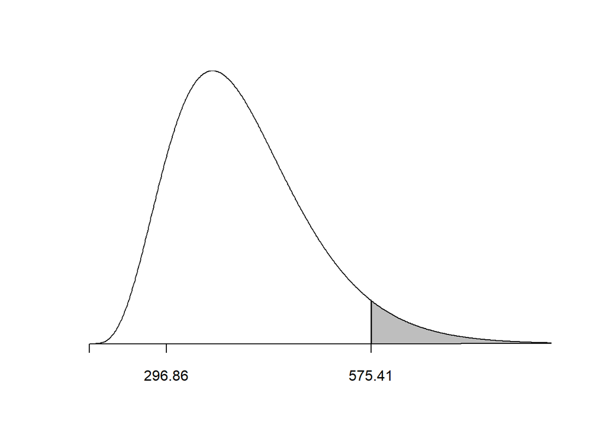

_Región de rechazo: a la derecha de del valor crítico (575.41) (a la derecha por el simbolo $>$ en $H_1$), área de color gris. El estadístico de prueba, 296.86198 cae en Región de NO Rechazo.__

Tomando decisión a través del valor $p$:

```r
# valor p (unilateral)
pvalue <- pchisq(q = chi_calc, df = n-1, lower.tail = F)
# lower.tail = FALSE porque H1 tiene simbolo >

pvalue
```

```
[1] 1
```

```r
# lo redondea a 1 pero si miramos en el "Environment" vemo que ese valor es 0.99999999999999
```

5. Conclusión COMPLETA:
- Si concluyo con los valores críticos:

No existe evidencia suficiente para rechazar la $H_0$, ya que el estadístico de prueba se encuentra en la región de aceptación, por lo tanto no podemos rechazar que el desvío de pesos de los envases sea menor a 0.1 kg, y SENASA aceptará la comercialización del producto.

- Si concluyo con el valor $p$:

No existe evidencia suficiente para rechazar la $H_0$, ya que el valor $p$ (0.99) es mayor al nivel de significancia ($\alpha=0.01$), por lo tanto no podemos rechazar que el desvío de pesos de los envases sea menor a 0.1 kg, y SENASA aceptará la comercialización del producto.

# Resumen de aclaraciones de Pruebas de Hipótesis

**Distribución normal “z” y Distribución “t” de Student:**

Argumento `p` en las funciones `qnorm()` o `qt()`, para averiguar valores críticos:

- PH unilaterales (izquierda o derecha, $H_1$ tiene símbolo $<$ o $>$ respectivamente): `p = alpha`
- PH bilateral ($H_1$ tiene el simbolo $\ne$): `p = c(alfa/2,1-alfa/2)`

Argumento `lower.tail`, en las funciones `pnorm()` o `pt()`, para averiguar valor “p”:

- PH unilateral derecha ($H_1$ tiene el símbolo $>$): `lower.tail = F`
- PH unilateral izquierda ($H_1$ tiene el símbolo $<$): `lower.tail = T`
- PH bilaterales ($H_1$ tiene símbolo $\ne$):
  - si `z_calc` o `t_calc` < 0, entonces `lower.tail = T` y luego multiplicar por 2
  - si `z_calc` o `t_calc` > 0, entonces `lower.tail = F` y luego multiplicar por 2

**Distribución $\chi^2$:**

Argumento `p` en la función `qchisq()`, para averiguar valores críticos:

- PH unilaterales (izquierda o derecha, $H_1$ tiene símbolo $<$ o $>$ respectivamente): `p = alpha`
- PH bilateral ($H_1$ tiene el simbolo $\ne$): `p = c(alfa/2,1-alfa/2)`

Argumento `lower.tail` en la función `pchisq()`, para averiguar valor “p”:

- PH unilateral derecha ($H_1$ tiene el símbolo $>$): `lower.tail = F`
- PH unilateral izquierda ($H_1$ tiene el símbolo $<$): `lower.tail = T`
- PH bilaterales ($H_1$ tiene símbolo $\ne$):
  - si $s < \sigma_0$, entonces `lower.tail = T` y luego multiplicar por 2
  - si $s > \sigma_0$, entonces `lower.tail = F` y luego multiplicar por 2

Material preparado por [Cátedra de Estadística FCA-UNL](https://github.com/estadistica-fca/)